# Simulation-2

Jesse

2019年10月22日

We’ve learnt to build a simulation experiment with what we’ve learnt so far.  
Today, we are going to try building one more simulation, and practice *function* and *for loop* with it.  
Let’s try visualize outcome of coin flipping.

# Coin Flipping (flipping 50 times)

Today, we gonna try coin flipping several times, and visualize their sample means.  
We gonna see the difference when we trying sampling coin flipping more times every try.  
As we wanna see the difference of sample means distribution when sampling times getting more,  
here we try sampling 20 times, 50 times, 100 times.

## First Step: Create vectors to store.

```r
coin_flipping_mean_20 = c()
coin_flipping_mean_50 = c()
coin_flipping_mean_100 = c()
```

## Second Step: Conduct sampling.

*Remember to set.seed() or you will get different rsults every time you run your code*

```r
set.seed(1215)
```

Then, here we do the sampling.

```r
for (i in 1:200) {
  sampling = rbinom(20, 50, 0.5)
  coin_flipping_mean_20[i] = mean(sampling)
}
for (i in 1:200) {
  sampling = rbinom(50, 50, 0.5)
  coin_flipping_mean_50[i] = mean(sampling)
}
for (i in 1:200) {
  sampling = rbinom(100, 50, 0.5)
  coin_flipping_mean_100[i] = mean(sampling)
}
```

### Question

As we see, we have to create three `for loop` to do the previous sampling.  
Can we do the previous thing by just using one `for loop`?How?  
Will the result being the same as we did?

## Third Step: Data Visulization

As we see, we can hardly find out anything by these numbers.

```r
coin_flipping_mean_20
```

```
##   [1] 26.25 26.20 25.25 24.80 24.55 25.45 24.15 26.95 25.65 25.00 25.25
##  [12] 23.95 25.85 26.50 25.25 24.75 24.35 24.90 26.25 24.25 25.95 25.50
##  [23] 24.15 24.35 24.15 26.80 25.10 23.45 23.10 26.10 24.60 25.45 26.10
##  [34] 24.15 25.40 23.85 25.00 25.15 23.60 23.70 26.25 23.50 25.05 25.15
##  [45] 25.85 25.25 25.85 24.50 25.25 23.85 24.35 24.90 25.70 23.50 24.45
##  [56] 24.55 25.60 24.25 25.25 24.85 24.70 24.95 25.65 23.55 23.65 26.00
##  [67] 26.30 25.70 25.05 25.45 25.90 26.20 26.70 26.95 24.50 24.40 25.55
##  [78] 24.65 23.65 24.20 25.05 26.45 24.20 25.75 25.40 24.95 25.25 25.30
##  [89] 24.10 25.35 25.00 24.65 25.30 24.40 24.10 22.30 24.60 25.00 25.45
## [100] 24.85 25.00 23.80 23.75 25.00 26.40 24.40 25.70 26.20 26.15 23.60
## [111] 25.15 26.40 23.25 25.70 23.90 25.05 25.15 25.75 25.20 25.35 25.20
## [122] 25.75 25.15 24.10 25.45 24.70 25.30 25.20 24.15 25.20 24.05 25.05
## [133] 24.40 24.75 25.75 24.80 24.15 24.05 24.25 25.80 24.20 26.20 25.05
## [144] 23.95 24.65 25.10 25.50 25.60 25.80 23.50 24.35 25.25 24.00 24.30
## [155] 25.60 24.60 24.75 24.70 24.30 24.10 24.90 23.70 24.45 25.10 24.80
## [166] 25.15 25.05 24.65 25.05 25.50 24.25 24.70 25.05 24.20 25.90 25.25
## [177] 25.10 25.40 25.30 23.35 25.90 24.15 25.05 25.25 25.50 24.05 25.05
## [188] 23.85 23.55 25.35 24.30 25.05 24.50 24.80 24.80 25.20 25.50 25.10
## [199] 25.40 25.20
```

```r
coin_flipping_mean_50
```

```
##   [1] 24.58 24.08 26.06 24.98 24.72 25.54 25.30 25.22 25.10 24.86 24.66
##  [12] 26.10 24.12 25.34 25.18 24.58 25.04 24.86 25.40 24.34 25.94 25.00
##  [23] 24.24 25.20 24.96 25.52 25.16 24.72 25.58 24.76 25.66 25.34 24.70
##  [34] 24.04 24.74 24.60 25.20 24.70 25.30 25.14 24.96 24.98 25.08 25.50
##  [45] 24.98 24.76 24.00 24.38 24.94 24.96 25.54 24.98 24.90 25.62 25.36
##  [56] 25.28 25.34 25.88 25.02 24.88 24.80 26.04 24.88 24.96 25.90 25.90
##  [67] 25.24 25.40 25.00 25.10 25.44 24.38 24.90 25.30 25.54 25.32 24.56
##  [78] 25.12 25.04 25.02 25.10 24.86 25.88 25.46 24.54 24.80 25.92 24.58
##  [89] 25.48 24.18 25.00 24.62 25.54 25.04 23.78 25.16 24.30 25.10 24.80
## [100] 25.28 25.28 25.02 25.46 25.58 25.80 24.28 24.94 24.02 25.06 24.80
## [111] 25.70 25.42 25.24 25.26 24.62 25.46 25.30 25.44 24.84 23.76 24.62
## [122] 24.64 24.36 25.18 25.44 25.06 24.74 24.86 24.56 25.42 25.28 24.92
## [133] 25.02 25.02 24.54 25.38 24.80 24.88 25.44 25.44 24.02 25.14 25.00
## [144] 24.54 24.56 24.98 25.30 24.62 24.04 25.16 24.56 25.70 25.18 26.26
## [155] 25.22 25.36 24.98 25.24 25.72 24.82 24.86 24.40 24.70 24.46 24.30
## [166] 25.18 24.96 25.68 25.36 25.28 24.22 25.88 25.42 25.90 25.76 25.30
## [177] 25.90 24.60 24.36 25.84 25.14 24.90 25.36 25.34 25.40 24.38 24.26
## [188] 25.10 26.12 24.60 25.52 24.86 24.50 24.26 25.70 24.62 24.70 24.92
## [199] 24.14 25.42
```

```r
coin_flipping_mean_100
```

```
##   [1] 25.17 25.03 25.08 24.50 25.27 24.66 25.51 25.09 24.91 24.42 24.29
##  [12] 24.80 24.99 25.15 25.45 24.57 24.89 25.12 23.83 24.55 25.54 25.27
##  [23] 24.96 25.46 25.17 24.76 24.88 24.94 25.64 24.26 24.39 24.63 24.96
##  [34] 25.24 24.68 25.23 25.13 25.23 25.31 25.17 25.15 24.75 24.80 24.61
##  [45] 24.40 24.88 24.93 24.88 24.94 25.00 24.44 25.25 24.26 24.72 24.94
##  [56] 24.64 25.07 24.96 24.25 25.13 25.66 24.57 25.22 24.56 25.07 24.67
##  [67] 24.36 25.38 24.86 25.14 24.92 24.87 24.80 25.31 24.96 24.96 25.48
##  [78] 24.98 24.62 24.10 24.86 25.05 24.74 24.84 25.01 24.96 25.19 24.57
##  [89] 25.34 24.36 25.29 24.97 25.15 24.92 24.79 25.02 24.48 25.17 24.52
## [100] 25.24 24.35 25.28 24.51 25.75 24.92 25.22 24.92 24.99 25.17 25.05
## [111] 25.28 24.36 25.70 25.14 24.72 24.72 25.43 25.02 25.19 24.94 25.35
## [122] 25.46 24.95 25.24 25.17 24.36 24.47 25.35 24.50 24.88 25.03 24.94
## [133] 24.80 24.74 24.56 24.30 24.52 25.93 25.55 24.69 24.29 24.72 25.17
## [144] 25.17 25.04 25.34 24.97 25.43 25.01 25.22 24.78 25.09 25.15 24.29
## [155] 24.81 25.36 24.92 24.93 25.07 25.37 24.92 25.15 24.65 24.67 25.48
## [166] 24.42 24.90 25.79 25.24 24.86 25.07 25.21 24.31 25.52 24.32 25.18
## [177] 24.95 24.74 23.94 25.23 25.47 24.78 25.04 24.96 25.33 25.10 25.33
## [188] 25.02 25.31 24.08 24.75 25.34 24.61 24.42 25.03 25.01 24.92 25.44
## [199] 24.82 24.56
```

Plots can help us more likely to discover new findings or consume information.  
Now we can do histrogram for 20, 50, 100 times to see the difference for easily.

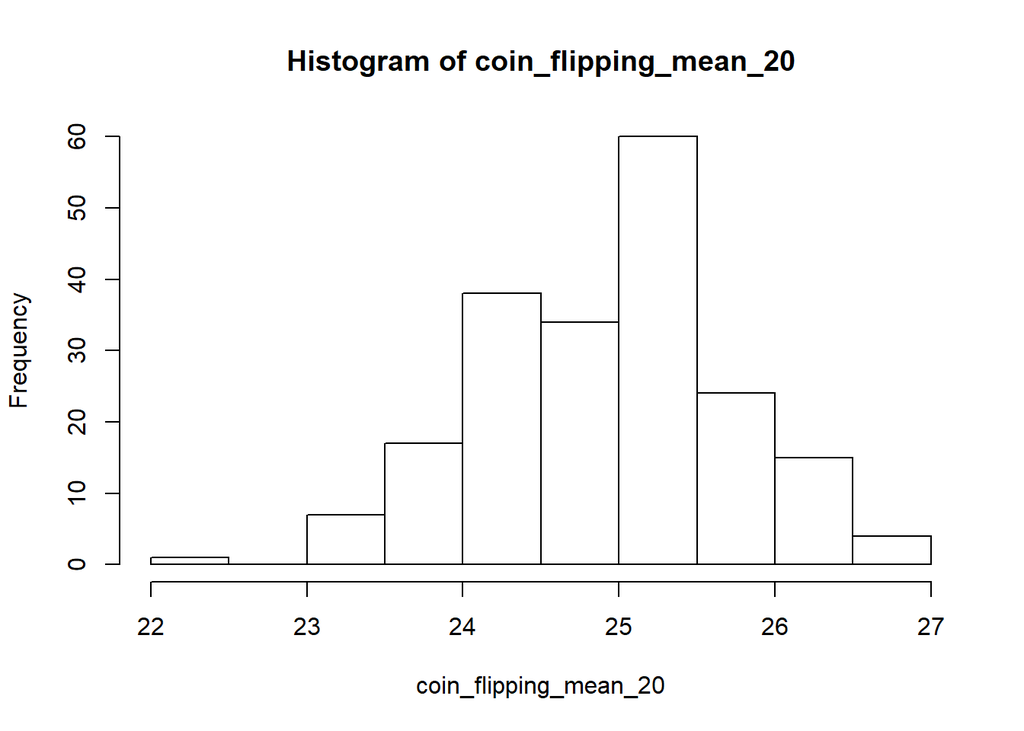

```r
hist(coin_flipping_mean_20)
```

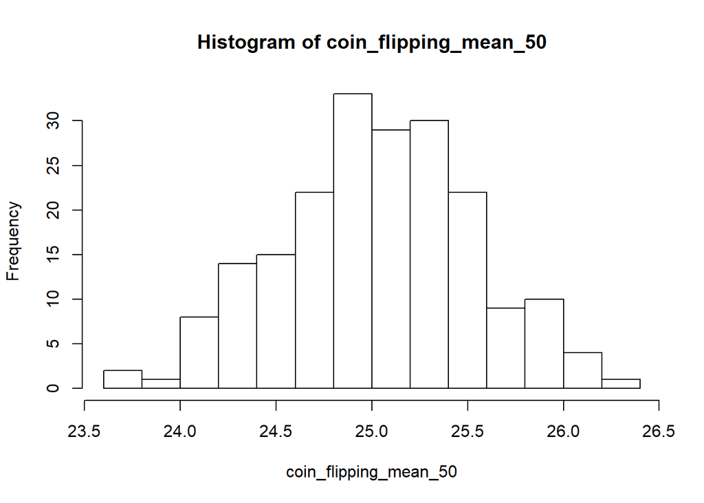

```r
hist(coin_flipping_mean_50)
```

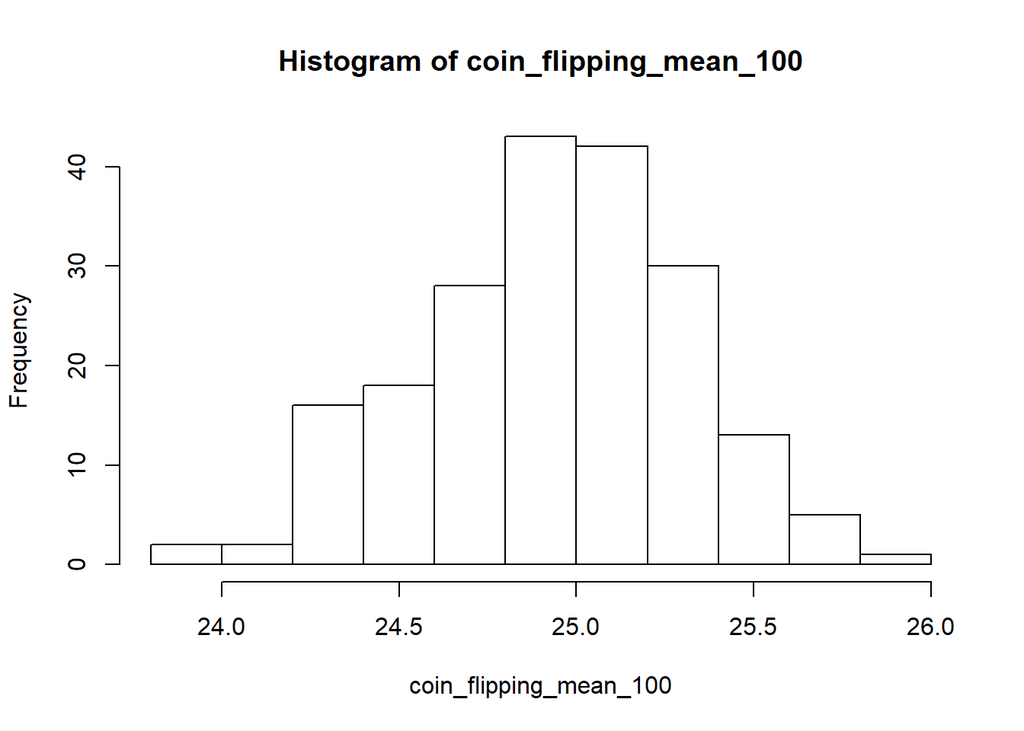

```r
hist(coin_flipping_mean_100)
```

## Fourth Step: Make functions.

### Question

Now we want to make a function where *sampling times* ,*flipping times*, and *how many sample means we want* being customizable. Try creating this function.